# R Notebook Stadistic

This code calculates True Positive Rates and False Positive Rates, as well as the Area Under the ROC Curve (AUC), to evaluate the performance of a classification model. Then, it creates a ROC curve plot with a diagonal reference line and a legend showing the AUC value.

```r
# Verificar los nombres de las columnas en train_set
#colnames(train_set)

# Asegurarse de que todas las columnas en 'variables' estén presentes en train_set
#all(variables %in% colnames(train_set))

# Definir las variables predictoras
variables <- c("radius_mean","texture_mean","perimeter_mean","area_mean","smoothness_mean","compactness_mean", "concavity_mean", "concave.points_mean","symmetry_mean","fractal_dimension_mean")

# Ajustar el modelo de regresión lineal
lm_model <- lm(diagnosis ~ ., data = train_set[, c(variables, "diagnosis")])
```

In this code:

- Predictor variables `variables` are defined, which include the features from the dataset that will be used to predict the response variable `diagnosis`.
- A linear regression model (`lm_model`) is fitted using the `lm()` function. The formula `diagnosis ~ .` is specified, meaning that the variable `diagnosis` is the response variable and all other variables specified in the dataset are used as predictor variables.
- The training set `train_set` is used and only the columns corresponding to the predictor variables and the response variable are selected.

```r
# Mostrar resumen del modelo
summary(lm_model)
```

```
Call:
lm(formula = diagnosis ~ ., data = train_set[, c(variables, "diagnosis")])

Residuals:
     Min       1Q   Median       3Q      Max
-0.82441 -0.16960  0.03542  0.18527  0.69882

Coefficients:
                         Estimate Std. Error t value Pr(>|t|)
(Intercept)             3.0187338  0.5160008   5.850 1.05e-08 ***
radius_mean            -0.4280016  0.1657898  -2.582 0.010202 *
texture_mean           -0.0220515  0.0036231  -6.086 2.78e-09 ***
perimeter_mean          0.0474319  0.0260577   1.820 0.069490 .
area_mean               0.0007938  0.0003527   2.251 0.024969 *
smoothness_mean        -2.2053753  1.6694113  -1.321 0.187265
compactness_mean        0.0466290  1.2490263   0.037 0.970239
concavity_mean         -0.6601000  0.5512686  -1.197 0.231876
concave.points_mean    -6.3789328  1.6646810  -3.832 0.000148 ***
symmetry_mean          -0.9357363  0.6492287  -1.441 0.150307
fractal_dimension_mean -0.7969845  4.9461098  -0.161 0.872072
---
Signif. codes:  0 ‘***’ 0.001 ‘**’ 0.01 ‘*’ 0.05 ‘.’ 0.1 ‘ ’ 1

Residual standard error: 0.2757 on 387 degrees of freedom
Multiple R-squared:  0.6749,    Adjusted R-squared:  0.6664
F-statistic: 80.32 on 10 and 387 DF,  p-value: < 2.2e-16
```

The model summary displays the estimated coefficients for each of the predictor variables included in the model. Here are some key points for interpreting the results:

*Intercept: The intercept value indicates the estimated value of the response variable (diagnosis) when all predictor variables are zero. In this case, the intercept is 3.0187338.

*p-values: The p-values indicate whether the coefficients are statistically significant. The smaller the p-value, the more significant the contribution of the predictor variable to the model. For example, radius_mean, texture_mean, area_mean, and concave.points_mean have significant p-values (below the typical significance level of 0.05), suggesting that these variables have a significant association with the response variable.

*R-squared: The R-squared is a measure of how well the data fit the model. In this case, the R-squared is 0.6749, meaning that approximately 67.49% of the variability in the response variable can be explained by the predictor variables included in the model.

*F-statistic: The F-statistic and its associated p-value are used to test the overall significance of the model. A small p-value for the F-statistic indicates that at least one of the predictor variables is significantly different from zero in relation to the response variable.

In summary, this model summary provides information on how the predictor variables are associated with the response variable (diagnosis) in the linear regression model.

```r
# Predecir en el conjunto de prueba
predictions <- predict(lm_model, newdata = test_set[, c(variables, "diagnosis")])
```

```r
# Evaluar el rendimiento del modelo
# Por ejemplo, puedes calcular el error cuadrático medio (MSE)
mse <- mean((predictions - test_set$diagnosis)^2)
mse
```

```
[1] 0.07540451
```

A mean squared error (MSE) of 0.0754 indicates that, on average, the predictions of the linear regression model deviate from the actual values by approximately 0.0754 squared units. As a general rule, the lower the MSE value, the better the model performance, as it indicates that the model predictions are closer to the actual values.

```r
# Calcular las tasas de verdaderos positivos y falsos positivos
roc_pred <- prediction(predictions, test_set$diagnosis)
roc_perf <- performance(roc_pred, "tpr", "fpr")

# Calcular el AUC
auc <- performance(roc_pred, "auc")
print(paste("Área bajo la curva ROC (AUC):", auc@y.values[[1]]))
```

```
[1] "Área bajo la curva ROC (AUC): 0.989236790606654"
```

```r
# Crear el gráfico de la curva ROC
plot(roc_perf, main = "Curva ROC", col = "blue", lwd = 2)

# Agregar línea de referencia diagonal
abline(a = 0, b = 1, lty = 2, col = "red")
```

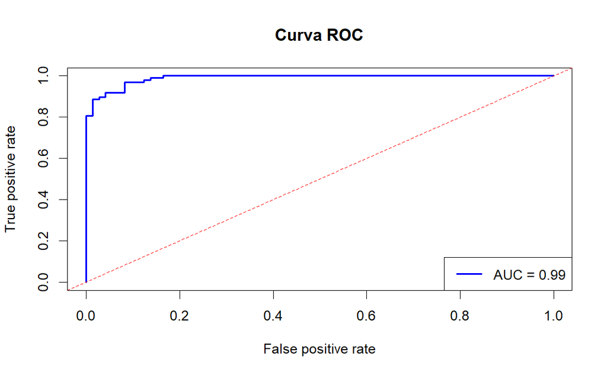

```r
# Agregar leyenda
legend("bottomright", legend = paste("AUC =", round(auc@y.values[[1]], 2)), col = "blue", lwd = 2)
```

This code calculates True Positive Rates and False Positive Rates, as well as the Area Under the ROC Curve (AUC), to evaluate the performance of a classification model. Then, it creates a ROC curve plot with a diagonal reference line and a legend showing the AUC value. After modifying the performance accuracy, the graph and the percentage of the value with an AUC of 0.99 will change accordingly.

end linear Regresion

```r
# Remove the 'id' column and the 'X' column
data_cancerGML <- data_cancerGML[, -1]  # Remove 'id' column
data_cancerGML <- data_cancerGML[, -ncol(data_cancerGML)]  # Remove last column (assuming it's 'X')
```

```r
# Fit the GLM model
# Define the formula
formula <- diagnosis ~ . - id - X

# Check if 'X' exists in the dataset
if ("X" %in% colnames(data_cancer)) {
  # Fit the GLM model
  glm_model <- glm(formula, data = data_cancer, family = binomial)
} else {
  print("Variable 'X' does not exist in the dataset.")
}
```

```
[1] "Variable 'X' does not exist in the dataset."
```

```r
# Assess the model's performance
summary(glm_model)
```

[output not shown]

```r
# Remove the 'id' column and the 'X' column
data_cancerGML <- data_cancerGML[, -1]  # Remove 'id' column
data_cancerGML <- data_cancerGML[, -ncol(data_cancerGML)]  # Remove last column (assuming it's 'X')

# Convert the 'diagnosis' variable to a binary factor
data_cancerGML$diagnosis <- as.factor(data_cancerGML$diagnosis)
```

[output not shown]

```r
# Preprocess the data (if needed)
# In this case, we will convert the diagnosis variable to a binary factor
data_cancerGML$diagnosis <- as.factor(data_cancerGML$diagnosis)
```

[output not shown]

```r
# Train the logistic regression model
logistic_model <- glm(diagnosis ~ ., data = train_set, family = binomial)
# Make predictions on the test set
predictions <- predict(logistic_model, newdata = test_set, type = "response")

# Convert predicted probabilities to classes (Malignant or Benign)
predicted_classes <- ifelse(predictions > 0.5, "M", "B")

# Evaluate model performance
confusion_matrix <- table(predicted_classes, test_set$diagnosis)
print(confusion_matrix)
```

```
predicted_classes  0  1
                B 71  4
                M  2 94
```

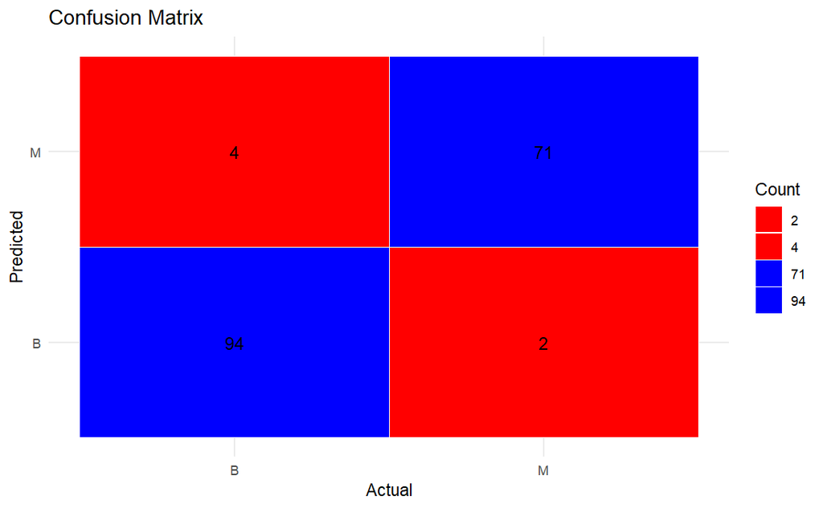

```r
# Visualize confusion matrix
confusion_df <- data.frame(
  Actual = rep(c("M", "B"), each = 2),
  Predicted = c("M", "B", "M", "B"),
  Count = c(confusion_matrix[1, 1], confusion_matrix[2, 1],
            confusion_matrix[1, 2], confusion_matrix[2, 2])
)

# Plot confusion matrix
ggplot(confusion_df, aes(x = Actual, y = Predicted, fill = factor(Count))) +
  geom_tile(color = "white") +
  geom_text(aes(label = Count)) +
  scale_fill_manual(values = c("#FF0000", "#FF0000", "#0000FF", "#0000FF"),
                    name = "Count") +
  theme_minimal() +
  labs(x = "Actual", y = "Predicted", title = "Confusion Matrix")
```

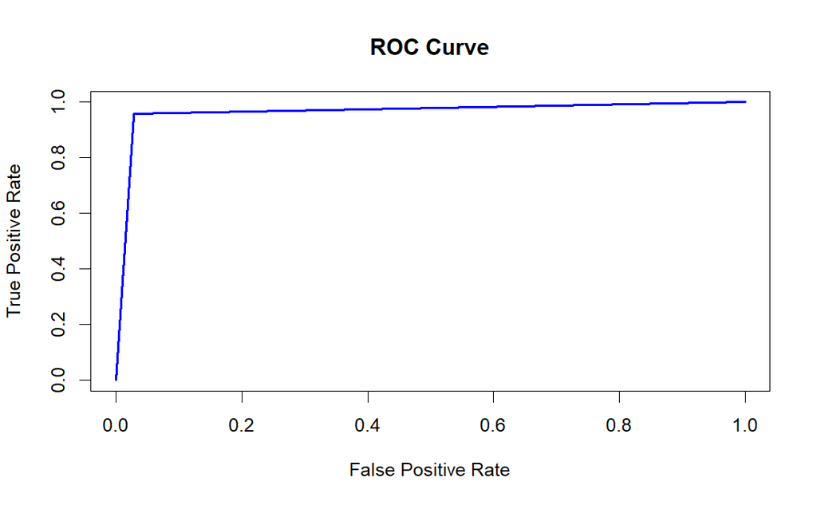

```r
# Calculate True Positive Rate and False Positive Rate
roc_pred <- prediction(predictions, test_set$diagnosis)
roc_perf <- performance(roc_pred, "tpr", "fpr")

# Plot ROC curve
plot(roc_perf, main = "ROC Curve",
     col = "blue", lwd = 2,
     xlab = "False Positive Rate",
     ylab = "True Positive Rate")
```

```r
# Calculate AUC
auc <- performance(roc_pred, "auc")
print(paste("Area Under the Curve (AUC):", auc@y.values[[1]]))
```

```
[1] "Area Under the Curve (AUC): 0.965753424657534"
```

```r
# Check the structure of the data_cancer dataframe
str(data_cancer)
```

```
'data.frame':   569 obs. of  31 variables:
 $ radius_mean            : num  18 20.6 19.7 11.4 20.3 ...
 $ texture_mean           : num  10.4 17.8 21.2 20.4 14.3 ...
 $ perimeter_mean         : num  122.8 132.9 130 77.6 135.1 ...
 $ area_mean              : num  1001 1326 1203 386 1297 ...
 $ smoothness_mean        : num  0.1184 0.0847 0.1096 0.1425 0.1003 ...
 $ compactness_mean       : num  0.2776 0.0786 0.1599 0.2839 0.1328 ...
 $ concavity_mean         : num  0.3001 0.0869 0.1974 0.2414 0.198 ...
 $ concave.points_mean    : num  0.1471 0.0702 0.1279 0.1052 0.1043 ...
 $ symmetry_mean          : num  0.242 0.181 0.207 0.26 0.181 ...
 $ fractal_dimension_mean : num  0.0787 0.0567 0.06 0.0974 0.0588 ...
 $ radius_se              : num  1.095 0.543 0.746 0.496 0.757 ...
 $ texture_se             : num  0.905 0.734 0.787 1.156 0.781 ...
 $ perimeter_se           : num  8.59 3.4 4.58 3.44 5.44 ...
 $ area_se                : num  153.4 74.1 94 27.2 94.4 ...
```

[output cut: 17 more lines]

```r
# Make sure 'id' and 'X' are columns in your dataframe and not part of the formula
# If 'id' and 'X' are indeed columns that need to be excluded from the formula, make sure they are correctly specified

# Update the formula to exclude 'id' and 'X' if they are indeed columns
formula_glm <- as.formula("diagnosis ~ .")

# Fit the GLM model
glm_model <- glm(formula_glm, data = data_cancer, family = binomial)
# Assess the model's performance
summary(glm_model)
```

```
Call:
glm(formula = formula_glm, family = binomial, data = data_cancer)

Coefficients:
                          Estimate Std. Error z value Pr(>|z|)
(Intercept)              3.100e+06  2.816e+05  11.009  < 2e-16 ***
radius_mean             -2.611e+06  2.693e+05  -9.698  < 2e-16 ***
texture_mean            -2.106e+05  1.471e+04 -14.323  < 2e-16 ***
perimeter_mean          -1.585e+06  2.464e+04 -64.325  < 2e-16 ***
area_mean                1.400e+05  3.907e+03  35.828  < 2e-16 ***
smoothness_mean          1.640e+08  8.361e+06  19.618  < 2e-16 ***
compactness_mean         6.914e+06  3.213e+06   2.152 0.031382 *
concavity_mean          -1.120e+06  1.408e+06  -0.795 0.426683
concave.points_mean      1.846e+07  5.382e+06   3.430 0.000604 ***
symmetry_mean           -4.356e+07  7.772e+05 -56.045  < 2e-16 ***
fractal_dimension_mean   4.554e+07  2.169e+06  21.001  < 2e-16 ***
radius_se               -3.581e+07  1.169e+06 -30.639  < 2e-16 ***
texture_se              -6.852e+06  2.005e+05 -34.173  < 2e-16 ***
perimeter_se            -1.830e+06  4.720e+04 -38.766  < 2e-16 ***
area_se                  6.879e+05  1.835e+04  37.483  < 2e-16 ***
smoothness_se           -8.060e+08  1.224e+07 -65.855  < 2e-16 ***
compactness_se           1.908e+08  5.732e+06  33.278  < 2e-16 ***
concavity_se            -1.645e+08  5.341e+06 -30.796  < 2e-16 ***
concave.points_se        1.355e+09  4.013e+07  33.781  < 2e-16 ***
symmetry_se             -3.109e+08  4.126e+06 -75.367  < 2e-16 ***
fractal_dimension_se    -1.627e+09  6.597e+07 -24.661  < 2e-16 ***
radius_worst             6.595e+06  2.143e+05  30.777  < 2e-16 ***
texture_worst            6.275e+05  2.437e+04  25.751  < 2e-16 ***
perimeter_worst          3.807e+05  1.219e+04  31.226  < 2e-16 ***
area_worst              -9.630e+04  2.741e+03 -35.135  < 2e-16 ***
smoothness_worst         2.325e+07  3.298e+06   7.050 1.79e-12 ***
compactness_worst       -9.668e+06  3.999e+05 -24.176  < 2e-16 ***
concavity_worst          3.258e+07  1.523e+06  21.384  < 2e-16 ***
concave.points_worst    -1.540e+08  5.471e+06 -28.147  < 2e-16 ***
symmetry_worst           2.661e+07  3.392e+05  78.454  < 2e-16 ***
fractal_dimension_worst  3.979e+07  5.340e+06   7.452 9.19e-14 ***
---
Signif. codes:  0 ‘***’ 0.001 ‘**’ 0.01 ‘*’ 0.05 ‘.’ 0.1 ‘ ’ 1

(Dispersion parameter for binomial family taken to be 1)

    Null deviance:   751.44  on 568  degrees of freedom
Residual deviance: 32006.76  on 538  degrees of freedom
AIC: 32069

Number of Fisher Scoring iterations: 25
```

```r
# Assume you have trained a logistic regression model (logistic_model) or a GLM model (glm_model) already

# Step 1: Train Sequence Model

# Step 2: Extract Features
sequence_features <- predict(logistic_model, newdata = data_cancer, type = "response")
# Or
sequence_features <- predict(glm_model, newdata = data_cancer, type = "response")

# Step 3: Train Clustering Model (e.g., K-means)
library(stats)
num_clusters <- 3  # Number of clusters
clustering_model <- kmeans(sequence_features, centers = num_clusters)

# Step 4: Use clustering results for further analysis or decision-making
cluster_labels <- clustering_model$cluster
# You can integrate cluster_labels with your predictions or analyze the clusters further

# Step 5: Evaluate models separately and jointly

# Step 6: Integrate and deploy as needed
```